# Bank Marketing Exercise

Replication code

Deyu Wang (5796695)

23 November 2026

```r
library(tidyverse)
library(emmeans)
library(knitr)
```

```r
r2 <- function(x) formatC(x, format = "f", digits = 2)
r4 <- function(x) formatC(x, format = "f", digits = 4)
pct <- function(x) formatC(100 * x, format = "f", digits = 1)
fmt_p <- function(p) {
  if (p < .001) "< .001" else paste0("= ", sub("^0", "", sprintf("%.3f", p)))
}
```

# 1. Read the data

```r
bank <- read_delim("bank-additional-full.csv", delim = ";")
bank
```

```
## # A tibble: 41,188 × 21
##      age job   marital education default housing loan  contact month day_of_week
##    <dbl> <chr> <chr>   <chr>     <chr>   <chr>   <chr> <chr>   <chr> <chr>
##  1    56 hous… married basic.4y  no      no      no    teleph… may   mon
##  2    57 serv… married high.sch… unknown no      no    teleph… may   mon
##  3    37 serv… married high.sch… no      yes     no    teleph… may   mon
##  4    40 admi… married basic.6y  no      no      no    teleph… may   mon
##  5    56 serv… married high.sch… no      no      yes   teleph… may   mon
##  6    45 serv… married basic.9y  unknown no      no    teleph… may   mon
##  7    59 admi… married professi… no      no      no    teleph… may   mon
##  8    41 blue… married unknown   unknown no      no    teleph… may   mon
##  9    24 tech… single  professi… no      yes     no    teleph… may   mon
## 10    25 serv… single  high.sch… no      yes     no    teleph… may   mon
## # ℹ 41,178 more rows
## # ℹ 11 more variables: duration <dbl>, campaign <dbl>, pdays <dbl>,
## #   previous <dbl>, poutcome <chr>, emp.var.rate <dbl>, cons.price.idx <dbl>,
## #   cons.conf.idx <dbl>, euribor3m <dbl>, nr.employed <dbl>, y <chr>
```

The columns in this file are separated by semicolons, not commas, so `read_csv()` would put every row into one column. `read_csv2()` also reads semicolons, but it expects a comma as the decimal mark, and this file uses a point (for example `93.994`). So `read_delim()` with `delim = ";"` is the right one.

There are 41,188 rows, one for each person contacted.

# 2. Data dictionary

| Variable | Description |
| --- | --- |
| `y` | Did the person subscribe to a term deposit? `"yes"` or `"no"` |
| `month` | Month of the last contact with the person, `"mar"` to `"dec"` |

```r
bank <- bank %>%
  mutate(subscribed = as.numeric(y == "yes"),
         month = factor(month, levels = tolower(month.abb), labels = month.abb))
count(bank, y, subscribed)
```

```
## # A tibble: 2 × 3
##   y     subscribed     n
##   <chr>      <dbl> <int>
## 1 no             0 36548
## 2 yes            1  4640
```

`subscribed` is 1 for yes and 0 for no. `month` is now a factor in calendar order.

# 3. Proportion subscribing in each month

```r
by.month <- bank %>%
  group_by(month) %>%
  summarise(contacted = n(), subscribed = sum(subscribed)) %>%
  mutate(proportion = subscribed / contacted)
kable(by.month, digits = 3)
```

| month | contacted | subscribed | proportion |
| --- | --- | --- | --- |
| Mar | 546 | 276 | 0.505 |
| Apr | 2632 | 539 | 0.205 |
| May | 13769 | 886 | 0.064 |
| Jun | 5318 | 559 | 0.105 |
| Jul | 7174 | 649 | 0.090 |
| Aug | 6178 | 655 | 0.106 |
| Sep | 570 | 256 | 0.449 |
| Oct | 718 | 315 | 0.439 |
| Nov | 4101 | 416 | 0.101 |
| Dec | 182 | 89 | 0.489 |

```r
setdiff(month.abb, by.month$month)
```

```
## [1] "Jan" "Feb"
```

January and February are missing. Nobody was contacted in those months, so I drop these two levels from the factor.

```r
bank <- bank %>% mutate(month = droplevels(month))
by.month <- by.month %>% mutate(month = droplevels(month))
```

Overall 11.3% of people subscribed (4,640 of 41,188).

# 4. Logistic regression

```r
m.subscribed.by.month <- glm(subscribed ~ month, family = binomial, data = bank)
summary(m.subscribed.by.month)
```

```
##
## Call:
## glm(formula = subscribed ~ month, family = binomial, data = bank)
##
## Coefficients:
##             Estimate Std. Error z value Pr(>|z|)
## (Intercept)  0.02198    0.08560   0.257   0.7974
## monthApr    -1.37862    0.09829 -14.027   <2e-16 ***
## monthMay    -2.69893    0.09238 -29.217   <2e-16 ***
## monthJun    -2.16362    0.09657 -22.405   <2e-16 ***
## monthJul    -2.32994    0.09498 -24.531   <2e-16 ***
## monthAug    -2.15402    0.09505 -22.662   <2e-16 ***
## monthSep    -0.22619    0.12007  -1.884   0.0596 .
## monthOct    -0.26834    0.11394  -2.355   0.0185 *
## monthNov    -2.20332    0.10001 -22.031   <2e-16 ***
## monthDec    -0.06594    0.17122  -0.385   0.7001
## ---
## Signif. codes:  0 '***' 0.001 '**' 0.01 '*' 0.05 '.' 0.1 ' ' 1
##
## (Dispersion parameter for binomial family taken to be 1)
##
##     Null deviance: 28999  on 41187  degrees of freedom
## Residual deviance: 26823  on 41178  degrees of freedom
## AIC: 26843
##
## Number of Fisher Scoring iterations: 5
```

As an equation, `subscribed ~ month` is

$$\log\left(\frac{p_i}{1-p_i}\right) = \beta_0 + \beta_{\text{Apr}} \, \text{Apr}_i + \beta_{\text{May}} \, \text{May}_i + \dots + \beta_{\text{Dec}} \, \text{Dec}_i$$

where $p_i$ is the probability that person $i$ subscribes, and $\text{Apr}_i$ is 1 if person $i$ was last contacted in April and 0 if not, and so on for the other months. March is the reference level because it is the first level of `month`. So $\beta_0$ is the log odds of subscribing in March, and each of the other nine coefficients is the difference in log odds between that month and March.

# 5. Does the proportion differ between months?

```r
(month.test <- anova(m.subscribed.by.month, test = "Chisq"))
```

```
## Analysis of Deviance Table
##
## Model: binomial, link: logit
##
## Response: subscribed
##
## Terms added sequentially (first to last)
##
##
##       Df Deviance Resid. Df Resid. Dev  Pr(>Chi)
## NULL                  41187      28999
## month  9   2175.3     41178      26824 < 2.2e-16 ***
## ---
## Signif. codes:  0 '***' 0.001 '**' 0.01 '*' 0.05 '.' 0.1 ' ' 1
```

The proportion of people subscribing differs significantly between months, $\chi^2(9)=2175.27$, $p$ < .001.

# 6. Predicted probabilities

```r
(m.subscribed.by.month.emm <- emmeans(m.subscribed.by.month, ~ month, type = "response"))
```

```
##  month   prob      SE  df asymp.LCL asymp.UCL
##  Mar   0.5055 0.02140 Inf    0.4636    0.5473
##  Apr   0.2048 0.00787 Inf    0.1898    0.2206
##  May   0.0643 0.00209 Inf    0.0604    0.0686
##  Jun   0.1051 0.00421 Inf    0.0972    0.1136
##  Jul   0.0905 0.00339 Inf    0.0840    0.0973
##  Aug   0.1060 0.00392 Inf    0.0986    0.1139
##  Sep   0.4491 0.02080 Inf    0.4087    0.4902
##  Oct   0.4387 0.01850 Inf    0.4028    0.4753
##  Nov   0.1014 0.00471 Inf    0.0926    0.1111
##  Dec   0.4890 0.03710 Inf    0.4171    0.5614
##
## Confidence level used: 0.95
## Intervals are back-transformed from the logit scale
```

```r
predictions <- as_tibble(summary(m.subscribed.by.month.emm)) %>%
  select(month, prob, asymp.LCL, asymp.UCL)
by.month <- left_join(by.month, predictions, by = "month")

# there is one coefficient for each month, so the predictions are the same as the raw proportions
all.equal(by.month$proportion, by.month$prob)
```

```
## [1] TRUE
```

This is Table 1 in the write-up:

```r
table.1 <- by.month %>%
  mutate(Month = month,
         Contacted = format(contacted, big.mark = ","),
         Subscribed = format(subscribed, big.mark = ","),
         `Probability of subscribing [95% CI]` =
           paste0(pct(prob), "% [", pct(asymp.LCL), "%, ", pct(asymp.UCL), "%]")) %>%
  select(Month, Contacted, Subscribed, `Probability of subscribing [95% CI]`)
kable(table.1, align = "lrrr")
```

| Month | Contacted | Subscribed | Probability of subscribing [95% CI] |
| --- | --- | --- | --- |
| Mar | 546 | 276 | 50.5% [46.4%, 54.7%] |
| Apr | 2,632 | 539 | 20.5% [19.0%, 22.1%] |
| May | 13,769 | 886 | 6.4% [6.0%, 6.9%] |
| Jun | 5,318 | 559 | 10.5% [9.7%, 11.4%] |
| Jul | 7,174 | 649 | 9.0% [8.4%, 9.7%] |
| Aug | 6,178 | 655 | 10.6% [9.9%, 11.4%] |
| Sep | 570 | 256 | 44.9% [40.9%, 49.0%] |
| Oct | 718 | 315 | 43.9% [40.3%, 47.5%] |
| Nov | 4,101 | 416 | 10.1% [9.3%, 11.1%] |
| Dec | 182 | 89 | 48.9% [41.7%, 56.1%] |

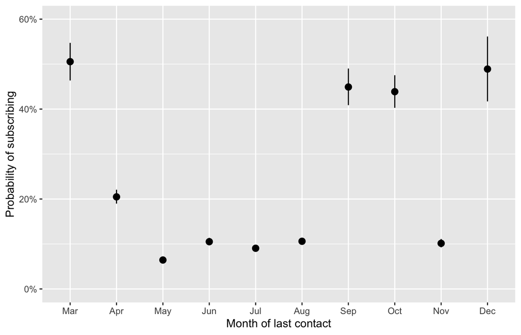

```r
figure.1 <- ggplot(by.month, aes(x = month, y = prob, ymin = asymp.LCL, ymax = asymp.UCL)) +
  geom_pointrange() +
  scale_y_continuous(labels = scales::percent, limits = c(0, 0.6)) +
  labs(x = "Month of last contact", y = "Probability of subscribing")
figure.1
```

The probability of subscribing is lowest in May, 6.4%, 95% CI [6.0%, 6.9%], and highest in March, 50.5%, 95% CI [46.4%, 54.7%]. March, September, October and December are all between 44% and 51%. The other six months are between 6% and 20%.

# 7. Odds of a subscription in September

```r
sep <- pred("Sep")
(odds.sep <- sep$prob / (1 - sep$prob))
```

```
## [1] 0.8152866
```

```r
# with a 95% CI, from the log odds
summary(emmeans(m.subscribed.by.month, ~ month)) %>%
  as_tibble() %>%
  filter(month == "Sep") %>%
  mutate(odds = exp(emmean), odds.LCL = exp(asymp.LCL), odds.UCL = exp(asymp.UCL)) %>%
  select(month, odds, odds.LCL, odds.UCL)
```

```
## # A tibble: 1 × 4
##   month  odds odds.LCL odds.UCL
##   <fct> <dbl>    <dbl>    <dbl>
## 1 Sep   0.815    0.691    0.962
```

The odds of a subscription in September are 0.82. Odds are the number of people who subscribed divided by the number who did not. So for every 100 people contacted in September who did not subscribe, about 82 did. The odds are below 1 because fewer than half subscribed (256 out of 570).

# 8. September by hand

```r
(b <- coef(summary(m.subscribed.by.month))[c("(Intercept)", "monthSep"), "Estimate"])
```

```
## (Intercept)    monthSep
##  0.02197891 -0.22619445
```

```r
log.odds.sep <- b[["(Intercept)"]] + b[["monthSep"]]
odds.sep.by.hand <- exp(log.odds.sep)
prob.sep.by.hand <- odds.sep.by.hand / (1 + odds.sep.by.hand)
c(log.odds = log.odds.sep, odds = odds.sep.by.hand, prob = prob.sep.by.hand)
```

```
##   log.odds       odds       prob
## -0.2042155  0.8152866  0.4491228
```

Log odds: intercept + September coefficient = 0.0220 + (-0.2262) = -0.2042

Odds: $\mathrm{e}^{-0.2042}$ = 0.8153

Probability: odds / (1 + odds) = 0.8153 / 1.8153 = 0.4491

This is the same as the prediction from `emmeans()` in question 6, 0.4491.

# 9. Why does the proportion vary over months?

```r
by.month %>% select(month, contacted, proportion) %>% arrange(contacted)
```

```
## # A tibble: 10 × 3
##    month contacted proportion
##    <fct>     <int>      <dbl>
##  1 Dec         182     0.489
##  2 Mar         546     0.505
##  3 Sep         570     0.449
##  4 Oct         718     0.439
##  5 Apr        2632     0.205
##  6 Nov        4101     0.101
##  7 Jun        5318     0.105
##  8 Aug        6178     0.106
##  9 Jul        7174     0.0905
## 10 May       13769     0.0643
```

```r
cor(log(by.month$contacted), by.month$proportion)
```

```
## [1] -0.9623039
```

The four months with the highest proportions (March, September, October and December) are the four months with the fewest people contacted, all under 750. In the other months more than 2,600 people were contacted, and in May 13,769.

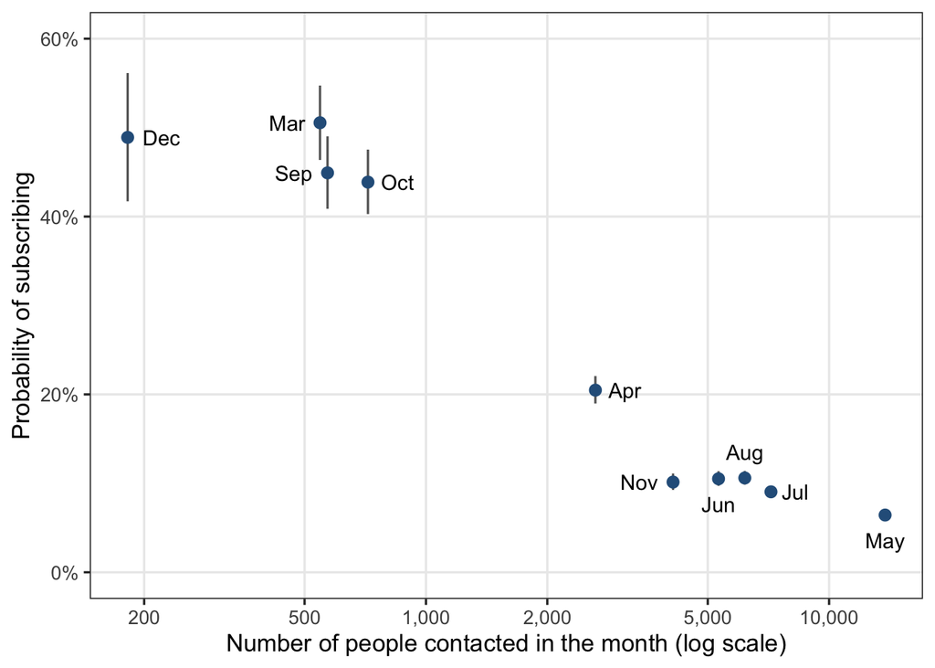

```r
# where each month label goes, so that it does not sit on a point or an error bar
label.hjust <- c(Mar = 1.4, Apr = -0.4, May = 0.5, Jun = 0.5, Jul = -0.4, Aug = 0.5, Sep = 1.4, Oct = -0.4, Nov = 1.4, Dec = -0.4)
label.vjust <- c(Mar = 0.5, Apr = 0.5, May = 2.2, Jun = 2.2, Jul = 0.5, Aug = -1.2, Sep = 0.5, Oct = 0.5, Nov = 0.5, Dec = 0.5)

figure.2 <- ggplot(by.month, aes(x = contacted, y = prob, ymin = asymp.LCL, ymax = asymp.UCL, label = month)) +
  geom_errorbar(width = 0, colour = "grey40") +
  geom_point(size = 2.5, colour = "#2C5F8A") +
  geom_text(aes(hjust = label.hjust[as.character(month)], vjust = label.vjust[as.character(month)]), size = 4) +
  scale_x_log10(breaks = c(200, 500, 1000, 2000, 5000, 10000), labels = scales::comma) +
  scale_y_continuous(labels = scales::percent, limits = c(0, 0.6)) +
  labs(x = "Number of people contacted in the month (log scale)",
       y = "Probability of subscribing") +
  theme_bw(base_size = 13) +
  theme(panel.grid.minor = element_blank())
figure.2
```

The fewer people the bank contacted in a month, the higher the proportion who subscribed. I do not think the calendar month itself is the reason. It looks more like the bank called different kinds of people in different months: a small selected group in the quiet months, and very large numbers of people in months like May.

One more column in the data supports this. `poutcome` is the outcome of the previous campaign for that person.

```r
previous.success <- bank %>%
  group_by(month) %>%
  summarise(contacted = n(),
            proportion.subscribed = mean(subscribed),
            proportion.previous.success = mean(poutcome == "success"))
kable(previous.success, digits = 3)
```

| month | contacted | proportion.subscribed | proportion.previous.success |
| --- | --- | --- | --- |
| Mar | 546 | 0.505 | 0.148 |
| Apr | 2632 | 0.205 | 0.042 |
| May | 13769 | 0.064 | 0.017 |
| Jun | 5318 | 0.105 | 0.027 |
| Jul | 7174 | 0.090 | 0.015 |
| Aug | 6178 | 0.106 | 0.033 |
| Sep | 570 | 0.449 | 0.260 |
| Oct | 718 | 0.439 | 0.189 |
| Nov | 4101 | 0.101 | 0.040 |
| Dec | 182 | 0.489 | 0.247 |

In the four quiet months, 15% to 26% of the people contacted had subscribed in a previous campaign. In the other months it was 2% to 4%. So the people called in the quiet months were probably more likely to say yes in any month.

# Other things to note

The campaigns ran from May 2008 to November 2010, so the same month can come from more than one year. With only `y` and `month` I cannot separate the month from the year or from who was called. The data are observational, so the differences between months are associations, not the effect of calling in a particular month.